# Health Tracker Analytics

Kevin Ajith

2023-07-29

# Summary

Bellabeat is a successful small company, but they have the potential to become a larger player in the global smart device market. Urška Sršen, cofounder and Chief Creative Officer of Bellabeat, believes that analyzing smart device fitness data could help unlock new growth opportunities for the company.

# Ask

### Business Task

Sršen asks us to analyze smart device usage data in order to gain insight into how consumers use non-Bellabeat smart devices. She then wants us to select one Bellabeat product to apply these insights to in our presentation. We have to find the following:

1. Understanding how customers use smart devices
2. Inform Bellabeat’s marketing strategy for growth
3. Get insights on key features to include in design of Bellabeat app or product to help with growth

### Stakeholder

1. Urška Sršen: Bellabeat’s Co-founder and Chief Creative Officer
2. Sando Mur: Mathematician and Bellabeat’s Co-founder; key member of the Bellabeat Executive team
3. Bellabeat marketing analytics team

# Prepare

### Overview of the Data

- Data is open-sourced
- Data is taken from [Zendo](https://zenodo.org/record/53894#.YMoUpnVKiP9)
- Data was uploaded by MORIUS
- Data was downloaded from [Kaggle](https://www.kaggle.com/datasets/arashnic/fitbit)
- There are 18 CSV files containing data
- The data has 33 unique Ids.
- Data contains fields like Intensities, Calories, Steps Taken, Distance Traveled and Sleep.
- Data has been measured daily, hourly as well as in minutes.

### Quality of Data

- The data is inconsistent since the data was last updated in 2016.
- The validation of data becomes difficult because of the above reason.
- The data did not have duplicate or null values.
- The data does not have identifiers for users as to protect the user information.
- The User Ids are inconsistent in some CSV files since it is much less than 30 user Ids.

# Process

### Filtering CSV

There is a lot of data and according to our requirement we need to have 30 ids for analysis. So we can remove data which do not meet the criteria. We can also remove data which are redundant or not required for analysis.

The Table for the CSV are as follows:

[output not shown]

After excluding the datasets which are not required, we are left with the following:

1. dailyActivity_merged
2. sleepDay_merged
3. hourlyCalories_merged
4. hourlyIntensities_merged
5. hourlySteps_merged

### Load The Libraries

The Libraries required for the project are:

1. tidyverse
2. dplyr

```r
library(tidyverse)
```

### Loading Dataset

```r
dailyActivity <- read.csv("C:/Users/kevin/Desktop/DA/Case Study DA/2/data/Fitabase Data 4.12.16-5.12.16/dailyActivity_merged.csv")
sleepDay <- read.csv("C:/Users/kevin/Desktop/DA/Case Study DA/2/data/Fitabase Data 4.12.16-5.12.16/sleepDay_merged.csv")
hourlyCalories <- read.csv("C:/Users/kevin/Desktop/DA/Case Study DA/2/data/Fitabase Data 4.12.16-5.12.16/hourlyCalories_merged.csv")
hourlyIntensities <- read.csv("C:/Users/kevin/Desktop/DA/Case Study DA/2/data/Fitabase Data 4.12.16-5.12.16/hourlyIntensities_merged.csv")
hourlySteps <- read.csv("C:/Users/kevin/Desktop/DA/Case Study DA/2/data/Fitabase Data 4.12.16-5.12.16/hourlySteps_merged.csv")
```

# Analyse

In the Analyse Stage, We will be organize and format the data as well as analyse it.

### Merge Hourly Activity Into hourlyActivity

The hourly activity is required because having different hourly data is redundant and becomes difficult to manage when it comes to analysis and it becomes easy to compare different fields in hourly activity.

```r
hourlyActivity <- merge(hourlyCalories, hourlyIntensities, by = c("Id","ActivityHour"))
hourlyActivity <- merge(hourlyActivity, hourlySteps, by = c("Id","ActivityHour"))
rm(hourlySteps,hourlyCalories,hourlyIntensities)
```

### Displaying Data

Before Analysis, Lets display the data in each of the data frame.

```r
#Head
head(dailyActivity)
```

|  | Id | ActivityDate | TotalSteps | TotalDistance | TrackerDistance | LoggedActivitiesDistance | VeryActiveDistance | ModeratelyActiveDistance | LightActiveDistance | SedentaryActiveDistance | VeryActiveMinutes | FairlyActiveMinutes | LightlyActiveMinutes | SedentaryMinutes | Calories |
| --- | --- | --- | --- | --- | --- | --- | --- | --- | --- | --- | --- | --- | --- | --- | --- |
| 1 | 1503960366 | 4/12/2016 | 13162 | 8.50 | 8.50 | 0 | 1.88 | 0.55 | 6.06 | 0 | 25 | 13 | 328 | 728 | 1985 |
| 2 | 1503960366 | 4/13/2016 | 10735 | 6.97 | 6.97 | 0 | 1.57 | 0.69 | 4.71 | 0 | 21 | 19 | 217 | 776 | 1797 |
| 3 | 1503960366 | 4/14/2016 | 10460 | 6.74 | 6.74 | 0 | 2.44 | 0.40 | 3.91 | 0 | 30 | 11 | 181 | 1218 | 1776 |
| 4 | 1503960366 | 4/15/2016 | 9762 | 6.28 | 6.28 | 0 | 2.14 | 1.26 | 2.83 | 0 | 29 | 34 | 209 | 726 | 1745 |
| 5 | 1503960366 | 4/16/2016 | 12669 | 8.16 | 8.16 | 0 | 2.71 | 0.41 | 5.04 | 0 | 36 | 10 | 221 | 773 | 1863 |
| 6 | 1503960366 | 4/17/2016 | 9705 | 6.48 | 6.48 | 0 | 3.19 | 0.78 | 2.51 | 0 | 38 | 20 | 164 | 539 | 1728 |

```r
head(hourlyActivity)
```

|  | Id | ActivityHour | Calories | TotalIntensity | AverageIntensity | StepTotal |
| --- | --- | --- | --- | --- | --- | --- |
| 1 | 1503960366 | 4/12/2016 1:00:00 AM | 61 | 8 | 0.133333 | 160 |
| 2 | 1503960366 | 4/12/2016 1:00:00 PM | 66 | 6 | 0.100000 | 221 |
| 3 | 1503960366 | 4/12/2016 10:00:00 AM | 99 | 29 | 0.483333 | 676 |
| 4 | 1503960366 | 4/12/2016 10:00:00 PM | 65 | 9 | 0.150000 | 89 |
| 5 | 1503960366 | 4/12/2016 11:00:00 AM | 76 | 12 | 0.200000 | 360 |
| 6 | 1503960366 | 4/12/2016 11:00:00 PM | 81 | 21 | 0.350000 | 338 |

```r
head(sleepDay)
```

|  | Id | SleepDay | TotalSleepRecords | TotalMinutesAsleep | TotalTimeInBed |
| --- | --- | --- | --- | --- | --- |
| 1 | 1503960366 | 4/12/2016 12:00:00 AM | 1 | 327 | 346 |
| 2 | 1503960366 | 4/13/2016 12:00:00 AM | 2 | 384 | 407 |
| 3 | 1503960366 | 4/15/2016 12:00:00 AM | 1 | 412 | 442 |
| 4 | 1503960366 | 4/16/2016 12:00:00 AM | 2 | 340 | 367 |
| 5 | 1503960366 | 4/17/2016 12:00:00 AM | 1 | 700 | 712 |
| 6 | 1503960366 | 4/19/2016 12:00:00 AM | 1 | 304 | 320 |

The data is loaded, the hourly activities are compiled into one and the datasets are displayed for the same.

### Data Transformation

The Id and date types are inconsistent since Id data type is number but we require it to be categorical data and date type is also inconsistent. Hence, we will streamline the data and then perform other analysis.

```r
#Change ID to category type
dailyActivity$Id <- as.character(dailyActivity$Id)
hourlyActivity$Id <- as.character(hourlyActivity$Id)
sleepDay$Id <- as.character(sleepDay$Id)

#Date and Time Transformation
dailyActivity$ActivityDate <- as.POSIXct(dailyActivity$ActivityDate, format = "%m/%d/%Y")

hourlyActivity$ActivityHour <- as.POSIXct(hourlyActivity$ActivityHour, format = "%m/%d/%Y %I:%M:%S %p", tz = Sys.timezone())
hourlyActivity$date <- format(hourlyActivity$ActivityHour, format = "%m/%d/%y")
hourlyActivity$time <- format(hourlyActivity$ActivityHour, format = "%H:%M:%S")

sleepDay$SleepDay <- as.POSIXct(sleepDay$SleepDay, format = "%m/%d/%Y %I:%M:%S %p", tz = Sys.timezone())
```

### Summaries

After the data transformation, we found that there are no duplicates as well as missing data in the chosen dataset. The summairs for their filds are as follows:

```r
#Summary
summary(dailyActivity)
```

```
##       Id             ActivityDate                      TotalSteps
##  Length:940         Min.   :2016-04-12 00:00:00.00   Min.   :    0
##  Class :character   1st Qu.:2016-04-19 00:00:00.00   1st Qu.: 3790
##  Mode  :character   Median :2016-04-26 00:00:00.00   Median : 7406
##                     Mean   :2016-04-26 06:53:37.01   Mean   : 7638
##                     3rd Qu.:2016-05-04 00:00:00.00   3rd Qu.:10727
##                     Max.   :2016-05-12 00:00:00.00   Max.   :36019
##  TotalDistance    TrackerDistance  LoggedActivitiesDistance VeryActiveDistance
##  Min.   : 0.000   Min.   : 0.000   Min.   :0.0000           Min.   : 0.000
##  1st Qu.: 2.620   1st Qu.: 2.620   1st Qu.:0.0000           1st Qu.: 0.000
##  Median : 5.245   Median : 5.245   Median :0.0000           Median : 0.210
##  Mean   : 5.490   Mean   : 5.475   Mean   :0.1082           Mean   : 1.503
##  3rd Qu.: 7.713   3rd Qu.: 7.710   3rd Qu.:0.0000           3rd Qu.: 2.053
##  Max.   :28.030   Max.   :28.030   Max.   :4.9421           Max.   :21.920
##  ModeratelyActiveDistance LightActiveDistance SedentaryActiveDistance
##  Min.   :0.0000           Min.   : 0.000      Min.   :0.000000
##  1st Qu.:0.0000           1st Qu.: 1.945      1st Qu.:0.000000
##  Median :0.2400           Median : 3.365      Median :0.000000
##  Mean   :0.5675           Mean   : 3.341      Mean   :0.001606
##  3rd Qu.:0.8000           3rd Qu.: 4.782      3rd Qu.:0.000000
##  Max.   :6.4800           Max.   :10.710      Max.   :0.110000
##  VeryActiveMinutes FairlyActiveMinutes LightlyActiveMinutes SedentaryMinutes
##  Min.   :  0.00    Min.   :  0.00      Min.   :  0.0        Min.   :   0.0
##  1st Qu.:  0.00    1st Qu.:  0.00      1st Qu.:127.0        1st Qu.: 729.8
##  Median :  4.00    Median :  6.00      Median :199.0        Median :1057.5
##  Mean   : 21.16    Mean   : 13.56      Mean   :192.8        Mean   : 991.2
##  3rd Qu.: 32.00    3rd Qu.: 19.00      3rd Qu.:264.0        3rd Qu.:1229.5
##  Max.   :210.00    Max.   :143.00      Max.   :518.0        Max.   :1440.0
##     Calories
##  Min.   :   0
##  1st Qu.:1828
##  Median :2134
##  Mean   :2304
##  3rd Qu.:2793
##  Max.   :4900
```

```r
summary(hourlyActivity)
```

```
##       Id             ActivityHour                       Calories
##  Length:22099       Min.   :2016-04-12 00:00:00.00   Min.   : 42.00
##  Class :character   1st Qu.:2016-04-19 01:00:00.00   1st Qu.: 63.00
##  Mode  :character   Median :2016-04-26 06:00:00.00   Median : 83.00
##                     Mean   :2016-04-26 11:46:42.58   Mean   : 97.39
##                     3rd Qu.:2016-05-03 19:00:00.00   3rd Qu.:108.00
##                     Max.   :2016-05-12 15:00:00.00   Max.   :948.00
##  TotalIntensity   AverageIntensity   StepTotal           date
##  Min.   :  0.00   Min.   :0.0000   Min.   :    0.0   Length:22099
##  1st Qu.:  0.00   1st Qu.:0.0000   1st Qu.:    0.0   Class :character
##  Median :  3.00   Median :0.0500   Median :   40.0   Mode  :character
##  Mean   : 12.04   Mean   :0.2006   Mean   :  320.2
##  3rd Qu.: 16.00   3rd Qu.:0.2667   3rd Qu.:  357.0
##  Max.   :180.00   Max.   :3.0000   Max.   :10554.0
##      time
##  Length:22099
##  Class :character
##  Mode  :character
##
##
##
```

```r
summary(sleepDay)
```

```
##       Id               SleepDay                      TotalSleepRecords
##  Length:413         Min.   :2016-04-12 00:00:00.00   Min.   :1.000
##  Class :character   1st Qu.:2016-04-19 00:00:00.00   1st Qu.:1.000
##  Mode  :character   Median :2016-04-27 00:00:00.00   Median :1.000
##                     Mean   :2016-04-26 12:40:05.80   Mean   :1.119
##                     3rd Qu.:2016-05-04 00:00:00.00   3rd Qu.:1.000
##                     Max.   :2016-05-12 00:00:00.00   Max.   :3.000
##  TotalMinutesAsleep TotalTimeInBed
##  Min.   : 58.0      Min.   : 61.0
##  1st Qu.:361.0      1st Qu.:403.0
##  Median :433.0      Median :463.0
##  Mean   :419.5      Mean   :458.6
##  3rd Qu.:490.0      3rd Qu.:526.0
##  Max.   :796.0      Max.   :961.0
```

The data was found to be clean as well as consistent data. The data type was converted to the required type for analysis.

### Data Visualization

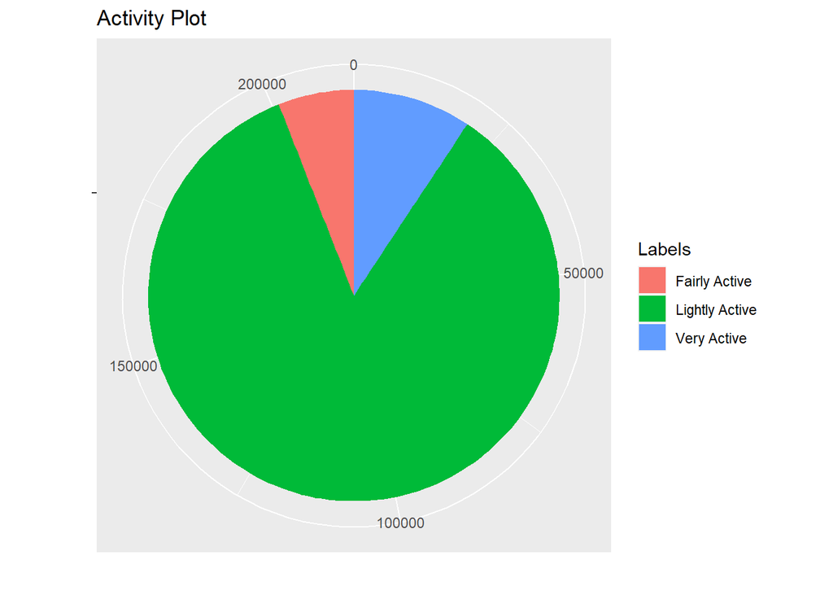

```r
VeryActive <- sum(dailyActivity$VeryActiveMinutes)
FairlyActive <- sum(dailyActivity$FairlyActiveMinutes)
LightlyActive <- sum(dailyActivity$LightlyActiveMinutes)


Activity_df = data.frame(
  "Activity_SUM" = c(VeryActive,FairlyActive,LightlyActive),
  "Labels" = c("Very Active", "Fairly Active", "Lightly Active")
  )

ggplot(Activity_df, aes(x = "", y = Activity_SUM, fill = Labels)) +
  geom_bar(stat="identity", width=1) +
  coord_polar(theta = "y") +
  labs(x = "", y = "", title = "Activity Plot")
```

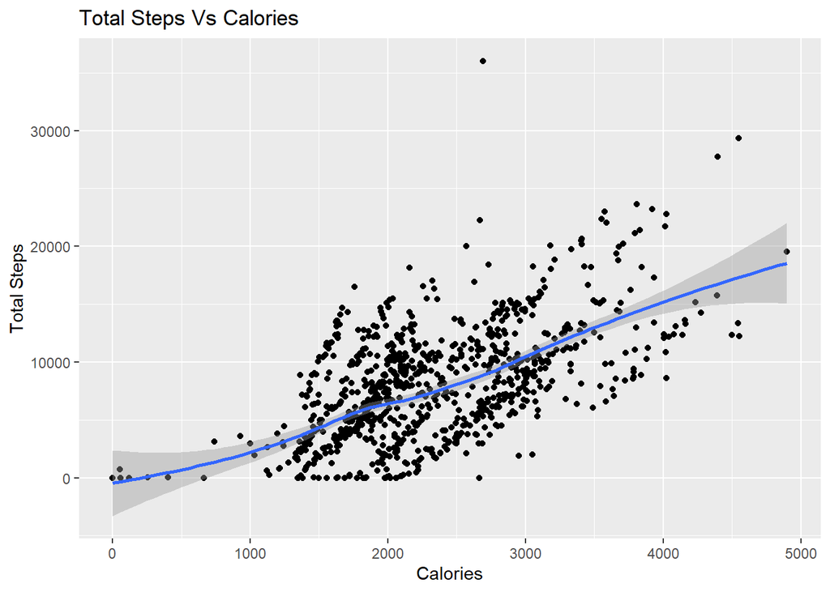

```r
ggplot(dailyActivity, aes(x = Calories, y = TotalSteps)) +
  geom_point() +
  labs( x = "Calories", y = "Total Steps", title = "Total Steps Vs Calories") +
  geom_smooth()
```

The above plot tells us that the TotalSteps has a positive correlation with Calories, i.e, The more steps you take more calories your burn, even though it may vary from user to user because of their metabolism.

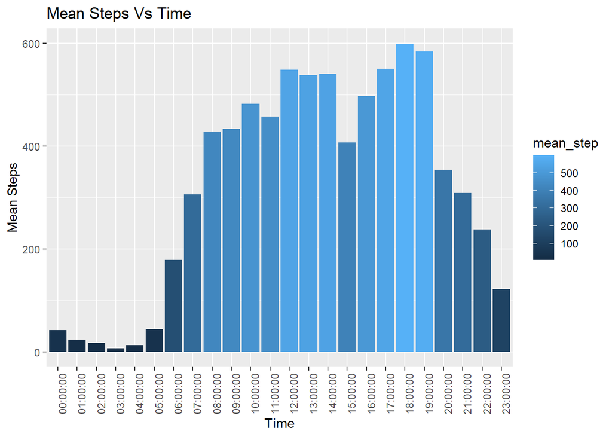

```r
ggplot(hourlyActivity %>% group_by(time) %>% summarise(mean_step=mean(StepTotal))) +
  geom_bar(aes(x = time, y = mean_step, fill = mean_step),stat = "identity") +
  labs( x = "Time", y = "Mean Steps", title = "Mean Steps Vs Time") +
  theme(axis.text.x = element_text(angle = 90))
```

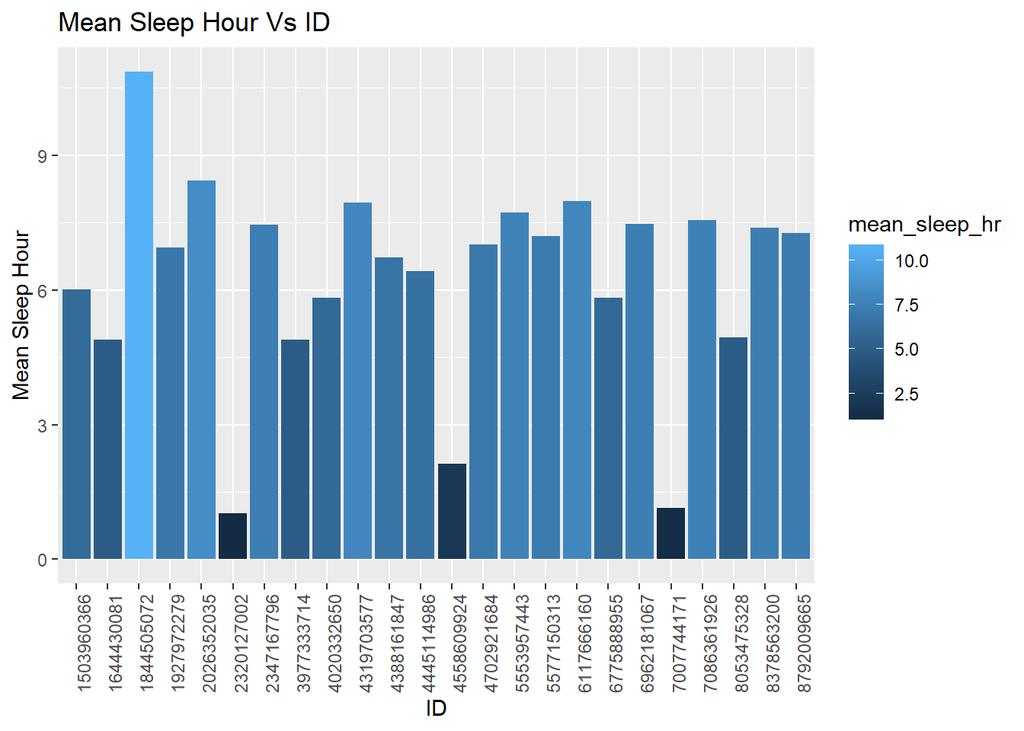

```r
ggplot(sleepDay %>% group_by(Id) %>% summarise(mean_sleep_hr = mean(TotalMinutesAsleep)/60)) +
  geom_bar(aes(x = Id, y = mean_sleep_hr, fill = mean_sleep_hr),stat = "identity") +
  labs( x = "ID", y = "Mean Sleep Hour", title = "Mean Sleep Hour Vs ID") +
  theme(axis.text.x = element_text(angle = 90))
```

According to the National Sleep Foundation, on an average an adult human requires sleep of 7 to 8 hours. Though the sample for sleep is available for 24 users only, It can be said that on average they sleep for 6.98 hours, from which we can say that there are users who do not meet the required standard when it comes to sleep.

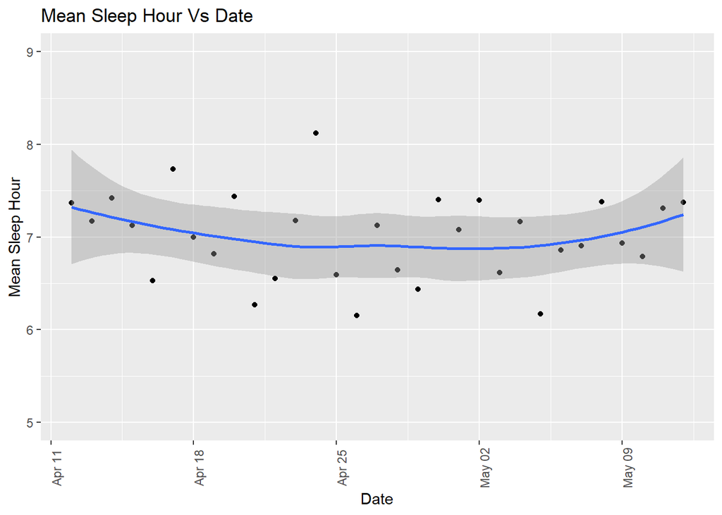

```r
ggplot(sleepDay %>% group_by(SleepDay) %>% summarise(mean_sleep_hr = mean(TotalMinutesAsleep)/60),
       aes(x = SleepDay, y = mean_sleep_hr)) +
  geom_point() +
  geom_smooth() +
  labs( x = "Date", y = "Mean Sleep Hour", title = "Mean Sleep Hour Vs Date") +
  theme(axis.text.x = element_text(angle = 90)) +
  ylim(5,9)
```

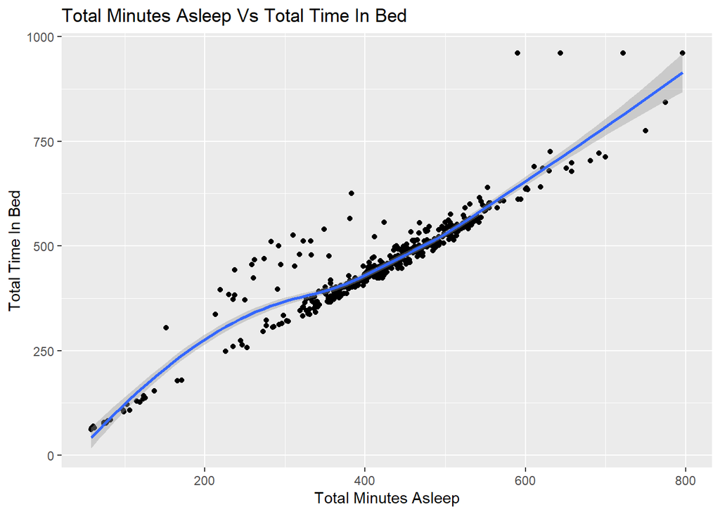

```r
ggplot(sleepDay, aes(x = TotalMinutesAsleep, y = TotalTimeInBed)) +
  labs( x = "Total Minutes Asleep", y = "Total Time In Bed",
        title = "Total Minutes Asleep Vs Total Time In Bed") +
  geom_point() + geom_smooth()
```

The data specifies that there is a correlation between sleep duration as well as time in bed, but in some cases people spend a lot time in bed before sleeping. Though it can be various number of reasons, we can assume that some of them may find it difficult to sleep.